# Part A

Laurel Abowd

2/13/2021

### B.

```r
# Read in data an convert to a tsibble
energy <- read_csv(here("data", "energy.csv"))
```

Explore the `energy` object as it currently exists. Notice that there is a column `month` that contains the month name, and 4-digit year. Currently, however, R understands that as a character (instead of as a date). Our next step is to convert it into a time series data frame (a *tsibble*), in two steps:

1. Add a new column (date) that is the current month column converted to a time series class, yearmonth
2. Convert the data frame to a tsibble, with that date column as the time index

Here’s what that looks like in a piped sequence:

```r
energy_ts <- energy %>%
  mutate(date = tsibble::yearmonth(month)) %>%
  as_tsibble(key = NULL, index = date)
```

### C. Exploratory time series visualization

#### Raw data graph

Exploratory data visualization is critical no matter what type of data we’re working with, including time series data. Let’s take a quick look at our tsibble for residential energy use, in trillion BTU.

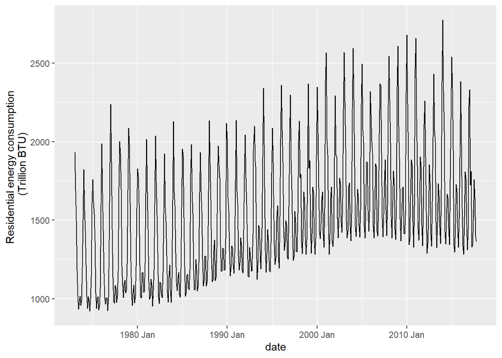

```r
ggplot(data = energy_ts, aes(x = date, y = res_total)) +
  geom_line() +
  labs(y = "Residential energy consumption \n (Trillion BTU)")
```

Looks like there are some interesting things happening. We should ask:

- Is there an overall trend?
- Is there seasonality?
- Any cyclicality evident?
- Any other notable patterns, outliers, etc.?

The big ones to notice quickly here are:

- Overall increasing trend overall, but stability (and possibly a slight decreasing trend) starting around 2005
- Clear seasonality, with a dominant seasonal feature and also a secondary peak each year - that secondary peak has increased substantially
- No notable cyclicality or outliers

#### Seasonplot:

A seasonplot can help point out seasonal patterns, and help to glean insights over the years. We’ll use `feasts::gg_season()` to create an exploratory seasonplot, which has month on the x-axis, energy consumption on the y-axis, and each year is its own series (mapped by line color).

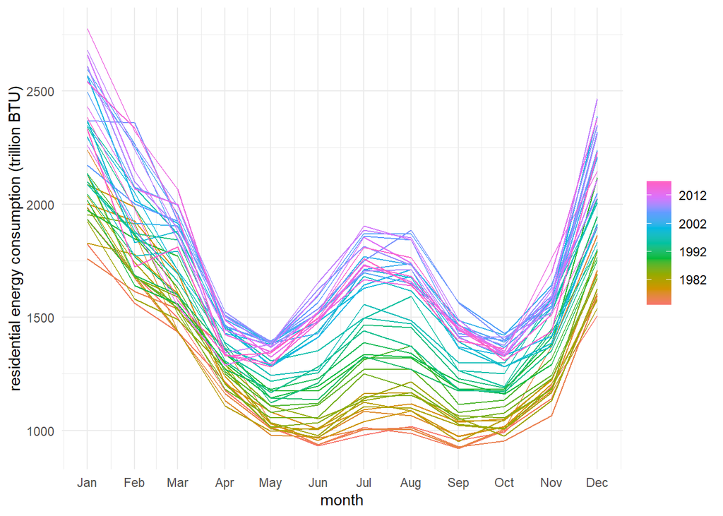

```r
energy_ts %>%
  gg_season(y = res_total) +
  theme_minimal() +
  labs(x = "month",
       y = "residential energy consumption (trillion BTU)")
```

This is really useful for us to explore both seasonal patterns, and how those seasonal patterns have changed over the years of this data (1973 - 2017). What are the major takeaways from this seasonplot?

- The highest residential energy usage is around December / January / February
- There is a secondary peak around July & August (that’s the repeated secondary peak we see in the original time series graph)
- We can also see that the prevalence of that second peak has been increasing over the course of the time series: in 1973 (orange) there was hardly any summer peak. In more recent years (blue/magenta) that peak is much more prominent.

Let’s explore the data a couple more ways:

#### Subseries plot:

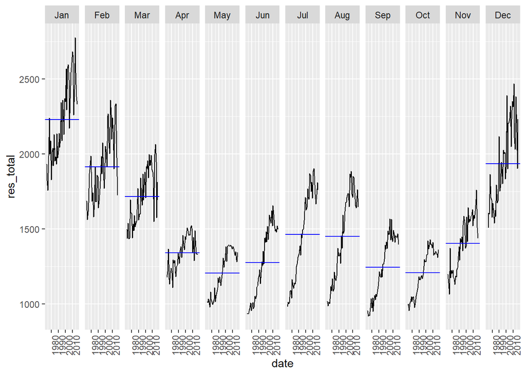

```r
energy_ts %>%  gg_subseries(res_total)
```

Our takeaway here is similar: there is clear seasonality (higher values in winter months), with an increasingly evident second peak in June/July/August. This reinforces our takeaways from the raw data and seasonplots.

#### Decomposition (here by STL)

See Rob Hyndman’s section on [STL decomposition](https://otexts.com/fpp2/stl.html) to learn how it compares to classical decomposition we did last week: “STL is a versatile and robust method for decomposing time series. STL is an acronym for “Seasonal and Trend decomposition using Loess”, while Loess is a method for estimating nonlinear relationships."

Notice that it allows seasonality to vary over time (a major difference from classical decomposition, and important here since we do see changes in seasonality).

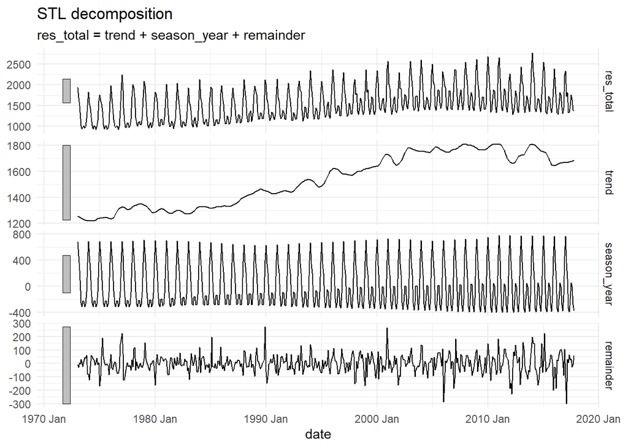

```r
# Find STL decomposition
dcmp <- energy_ts %>%
  model(STL(res_total ~ season()))

# View the components
# components(dcmp)

# Visualize the decomposed components:
components(dcmp) %>% autoplot() +
  theme_minimal()
```

#### Autocorrelation function (ACF)

We use the ACF to explore autocorrelation (here, we would expect seasonality to be clear from the ACF):

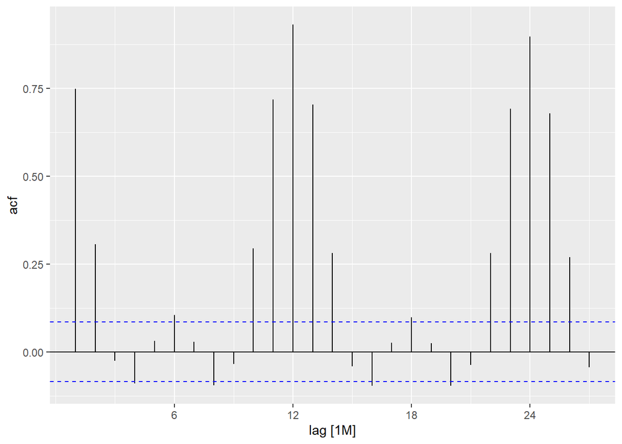

```r
energy_ts %>%
  ACF(res_total) %>%
  autoplot()
```

And yep, we see that observations separated by 12 months are the most highly correlated, reflecting strong seasonality we see in all of our other exploratory visualizations.

### D. Forecasting by Holt-Winters exponential smoothing

Note: here we use ETS, which technically uses different optimization than Holt-Winters exponential smoothing, but is otherwise the same (From [Rob Hyndman](https://stackoverflow.com/questions/60832182/holt-winters-forecast-in-r): “The model is equivalent to the one you are fitting with HoltWinters(), although the parameter estimation in ETS() uses MLE.”)

To create the model below, we specify the model type (exponential smoothing, ETS), then tell it what type of seasonality it should assume using the `season("")` expression, where “N” = non-seasonal (try changing it to this to see how unimpressive the forecast becomes!), “A” = additive, “M” = multiplicative. Here, we’ll say seasonality is multiplicative due to the change in variance over time and also within the secondary summer peak:

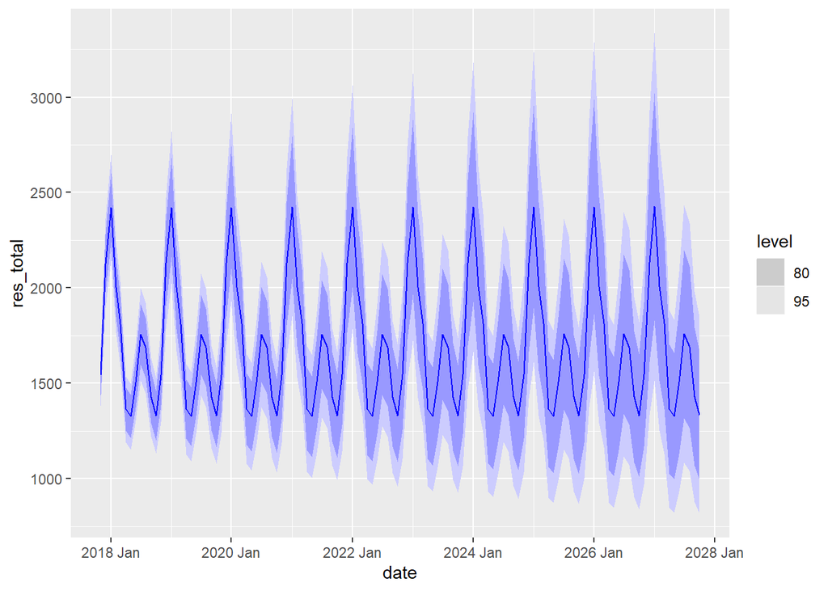

```r
# Create the model
energy_fit <- energy_ts %>%
  model(
    ets = ETS(res_total ~ season("M"))
  )

# Forecast using the model 10 years into the future:
energy_forecast <- energy_fit %>%
  forecast(h = "10 years")

# Plot just the forecasted values (with 80 & 95% CIs)
energy_forecast %>%
  autoplot()
```

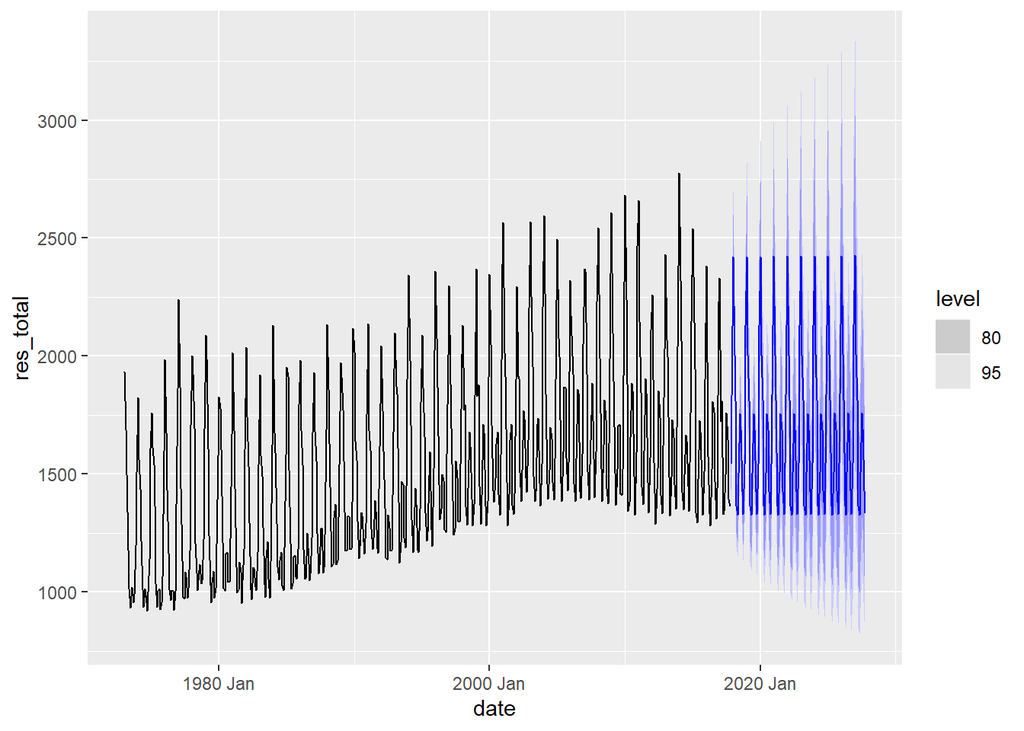

```r
# Or plot it added to the original data:
energy_forecast %>%
  autoplot(energy_ts)
```

#### Assessing residuals

We can use `broom::augment()` to append our original tsibble with what the model *predicts* the energy usage would be based on the model. Let’s do a little exploring through visualization.

First, use `broom::augment()` to get the predicted values & residuals:

```r
# Apprend the predicted values (and residuals) to original energy data
energy_predicted <- broom::augment(energy_fit)
```

Now, plot the actual energy values (res_total), and the predicted values (stored as .fitted) atop them:

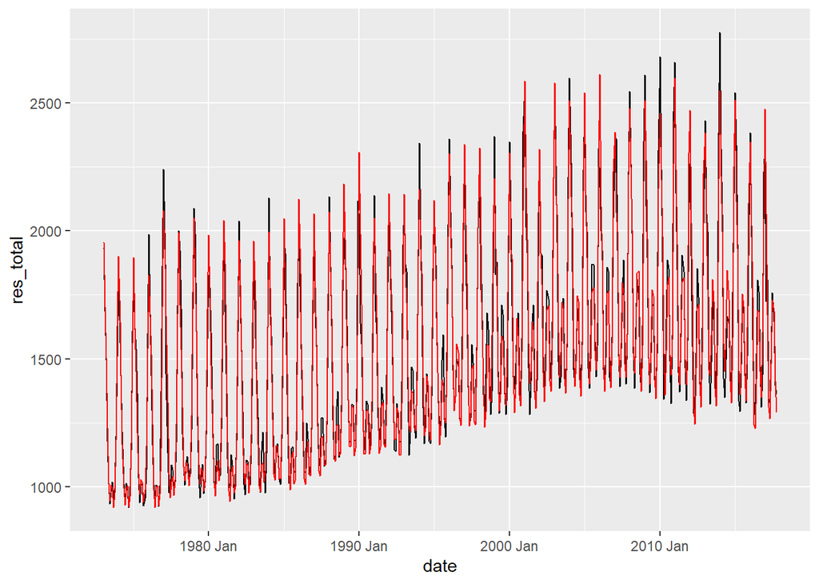

```r
ggplot(data = energy_predicted) +
  geom_line(aes(x = date, y = res_total)) +
  geom_line(aes(x = date, y = .fitted), color = "red")
```

Cool, those look like pretty good predictions!

Now let’s explore the **residuals**. Remember, some important considerations: Residuals should be uncorrelated, centered at 0, and ideally normally distributed. One way we can check the distribution is with a histogram:

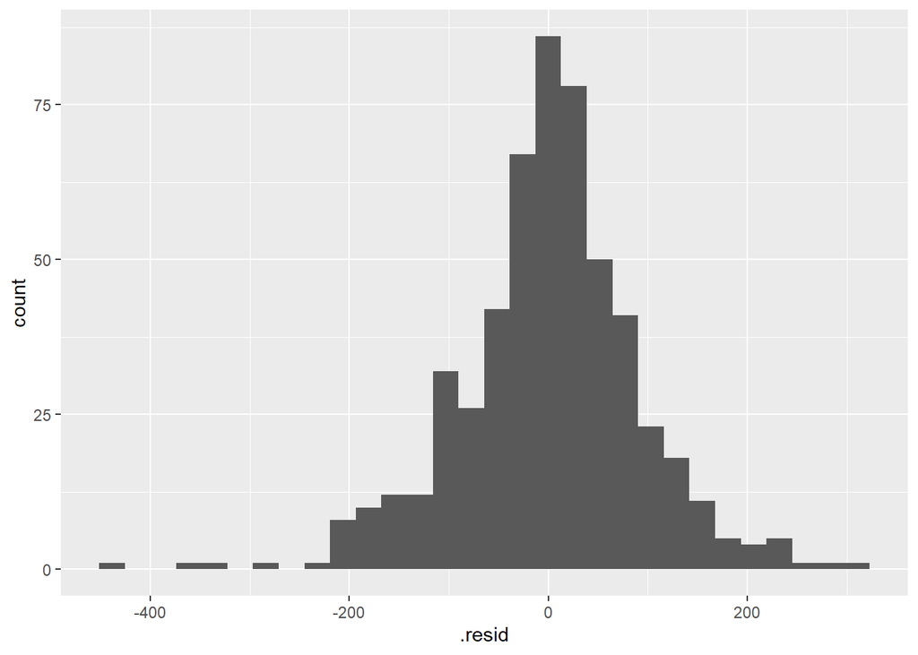

```r
ggplot(data = energy_predicted, aes(x = .resid)) +
  geom_histogram()
```